# ALU Data Analyst Assessment

Abigail Nzambi

2026-02-11

# Executive Summary

This analysis uses the [Higher Education Students Performance Evaluation](https://www.kaggle.com/datasets/mariazhokhova/higher-education-students-performance-evaluation) from Kaggle, from the Faculty of Engineering and Faculty of Educational Sciences students in 2019. This data contains student-level information on demographics, family background, socioeconomic indicators, study behaviors, and academic outcomes.

Although the dataset does not represent all African education systems, it provides a realistic view of student experiences and behaviors that are often missing from most real public data sets (e.g., World Bank, UNESCO). It was selected for its focus on individual students, making it especially relevant for an institution like ALU, where understanding engagement and learning behaviors is key to improving outcomes.

The analysis explores the **demographic**, **socioeconomic**, and **behavioral** factors influencing academic success, structured around five questions that combine descriptive, diagnostic, and predictive approaches to generate actionable insights.

# Methodology

## Data Source & Context

The dataset comprises **145 student records** from a higher education institution, capturing individual-level information across 33 variables. Data was originally coded numerically and transformed into categorical factors for interpretability. The dataset includes:

- **Demographic variables**: Age, gender, accommodation type, transportation mode
- **Socioeconomic indicators**: Scholarship type, family income, parental education and occupation
- **Academic behaviors**: Study hours, class attendance, reading habits, note-taking, exam preparation strategies
- **Outcome measures**: Course grades (0-7 scale), which were transformed into performance categories

## Data Preparation

### 1. Data Cleaning & Feature Engineering

- **Categorical transformation**: All 33 numeric variables were converted to meaningful categorical factors using the data dictionary provided on Kaggle
- **Outcome variable creation**: Three outcome variables were derived from the original grade variable:
  - `Grade_Numeric` (0-7): Continuous measure for correlation and regression analyses
  - `Performance` (Low/Medium/High): Categorical grouping where High ≥ 5, Medium ≥ 3, Low < 3
  - `Pass_Fail` (Pass/Fail): Binary indicator where Pass ≥ 3
- **Missing value check**: No missing values were detected in the dataset

### 2. Variable Organization

Variables were grouped into four conceptual domains: - **Demographics** (10 variables): Personal characteristics and living situation - **Family Background** (6 variables): Parental education, occupation, and family structure - **Academic Behaviors** (17 variables): Study habits, engagement patterns, and learning strategies - **Course Identifiers**: Course enrollment information

## Analytical Approach

The analysis employs a multi-method approach combining descriptive, diagnostic, and predictive techniques:

### Descriptive Analysis (Q1, Q2)

- **Frequency distributions**: To understand population composition
- **Cross-tabulations**: To examine relationships between categorical variables
- **Summary statistics**: Mean grades, pass rates, and performance distributions by subgroup

### Diagnostic Analysis (Q3, Q4)

- **ANOVA (Analysis of Variance)**: To test whether mean grades differ significantly across study behavior categories
- **Correlation analysis**: To quantify the strength and direction of relationships between ordinal variables and academic performance
- **Effect size interpretation**: Using correlation coefficients where |r| < 0.3 indicates weak, 0.3-0.6 moderate, and > 0.6 strong associations

### Predictive Analysis (Q4)

- **Logistic regression**: To model the probability of passing as a function of multiple socioeconomic and behavioral predictors
- **Model specification**: Binary outcome (Pass/Fail) predicted by 7 key variables: Study Hours, Class Attendance, Scholarship Level, Family Income, Work Status, Note-Taking, and Scientific Reading
- **Interpretation framework**:
  - Odds Ratios (OR) > 1 indicate increased likelihood of passing
  - 95% Confidence Intervals that exclude 1.0 suggest meaningful effects
  - Statistical significance assessed at α = 0.05, though practical significance is also considered

## Limitations

1. **Sample size**: With 145 students, statistical power for detecting small effects is limited, particularly in subgroup analyses
2. **Cross-sectional design**: The data represents a single point in time, preventing causal inference
3. **Self-reported behaviors**: Study hours and reading habits may be subject to recall bias or social desirability
4. **Context specificity**: Findings may not generalize beyond the institutional context from which data was collected
5. **Model performance**: The logistic regression shows no statistically significant predictors at p < 0.05, indicating either weak effects, multicollinearity, or unmeasured confounders

# Q1: Demographic analysis and visualization

## Question: What are the demographic characteristics of the student population?

### Q1 a) Gender distribution

| Gender | Count | Percentage |
| --- | --- | --- |
| Female | 58 | 40 |
| Male | 87 | 60 |

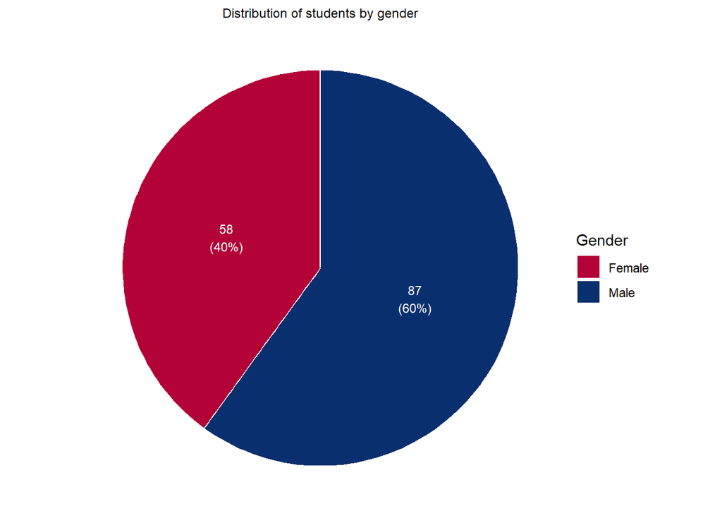

### Q1 b) Age group distribution

| Age Group | Count | Percentage |
| --- | --- | --- |
| 18-21 | 65 | 44.83 |
| 22-25 | 70 | 48.28 |
| 26+ | 10 | 6.90 |

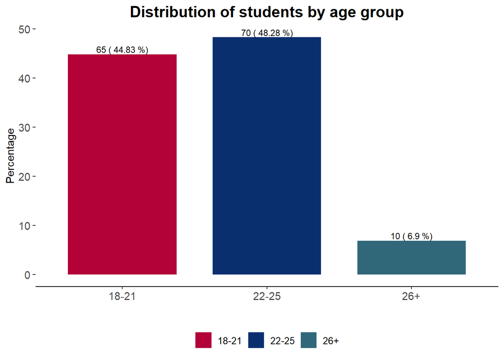

### Q1 c) Scholarship type distribution

| Scholarship Type | Count | Percentage |
| --- | --- | --- |
| None | 1 | 0.69 |
| 25% | 3 | 2.07 |
| 50% | 76 | 52.41 |
| 75% | 42 | 28.97 |
| Full | 23 | 15.86 |

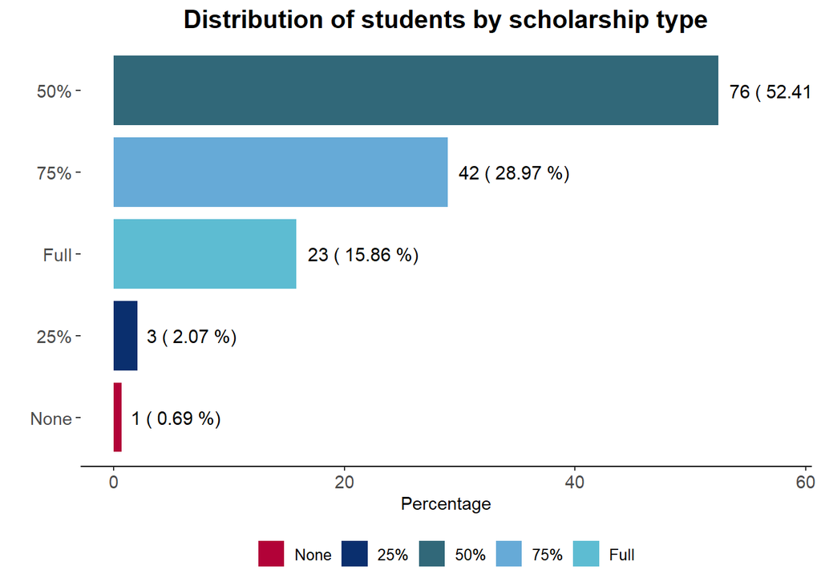

### Q1 d) Work status distribution

| Has Work | Count | Percentage |
| --- | --- | --- |
| Yes | 49 | 33.79 |
| No | 96 | 66.21 |

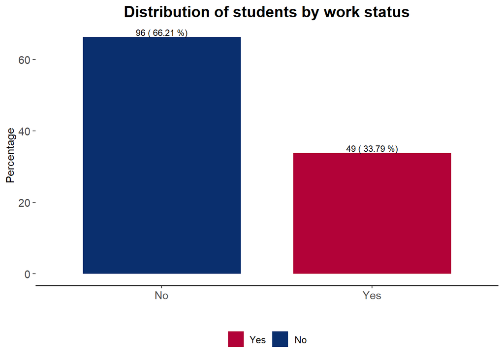